# Stat 331 Project Report

- Show All Code
- Hide All Code
- View Source

Author

Hailey Hossain, Zoey Miles, Ashley Navos, Vinithra Seshan

```r
library(tidyverse)
library(readr)
library(knitr)
library(gganimate)
library(broom)
library(kableExtra)
library(gifski)
```

## Introduction

Income and life expectancy have historically been shown to be correlated. At age 40, men in the top 1% income bracket are expected to live 14.6 years longer than those in the bottom 1%, and women can expect to live 10.1 years longer (Chetty et. al). We decided to explore the relationship between the income share of the middle 20% of individuals and life expectancy at birth to see how this correlation has changed throughout time and across countries.

The two variables that we are using are the Income Share of the Middle 20% and Life Expectancy at Birth. The Income Share of the Middle 20% is from the World Bank Group and measures the proportion of a country’s total income received by the middle 20% (third quintile). We have the proportions for each country and year, spanning 60 years. Life Expectancy at Birth is the average number of years a newborn child would live if current mortality patterns were to stay the same. The values were calculated using two main sources - the Human Mortality Database and the United Nations Population divisions World Population Prospects. We have estimates of Life Expectancy at Birth for each country and year, stretching over 200 years.

## Data Cleaning

The analysis may be impacted by how the data is sorted. The income share data set has income share by country and year, and we may see different results depending on the time frame or country we choose. The life expectancy at birth data set also has the option to sort by country and region, but has yearly data for life expectancy worldwide as well. The life expectancy dataset also has a “Notes and Uncertainty” section that writes about confounding factors affecting life expectancy, including pandemics, famines, war, and genocide. We did our best to account for these factors when cleaning the data.

When cleaning the data, we made the dataset for Life Expectancy smaller since it spanned 200 years. We chose the years 1950 to 2050 as the dataset for Income Share of the middle 20% only spans from 1963 to 2023. For the income dataset, the frequency of data varies from country to country, as some countries like the USA have values for every year while others are inconsistent or sparse. This was accounted for when joining the two data sets, producing a set which contained only data for countries and years that reported both values. This resulted in a large reduction of our data pool, as many countries had little or no data on income share for some reporting decades. Due to there being no clear pattern found in which values were missing, as well as the nature of our analysis, we felt it best to remove all missing values from both data sets, keeping only data points share by both sets of data.

```r
lex <- read_csv("lex.csv")

lex_long <- lex |>
  select(country,"1950":"2050") |>
  pivot_longer(cols = !country,
               names_to = "year",
               values_to = "life_ex")

income_share_middle <- read_csv("income_share_of_middle_20percent.csv")

income_share_long <- income_share_middle |>
  pivot_longer(cols = !country,
               names_to = "year",
               values_to = "income_share")

joined_data <- left_join(lex_long,
                         income_share_long,
                         join_by(country==country,year==year))

joined_data <- joined_data |>
  filter(!is.na(income_share)) |>
  mutate(year = as.numeric(year))
```

## Modeling The Relationship Between Life Expectancy and Income Share of the Middle 20%

**Plots**

The following plot illustrates the relationship between mean life expectancy and mean income share of the middle 20%, with each point representing a country. We will be using linear regression to visualize this data. We selected life expectancy as the response variable because our goal is to understand how it is affected by income distribution. The income share of the middle 20% serves as the explanatory variable, as we are investigating its potential influence on life expectancy. The plot was also fitted with a regression line for visual analysis, and on initial inspection, it appears there is a positive, moderately linear relationship between the two factors. It appears there is more variability for those who have a lower income share, but the overall trend appears consistently positive.This plot appears to indicate that as the income share of the middle 20% of individuals in a country increases, that country’s life expectancy at birth will also increase.

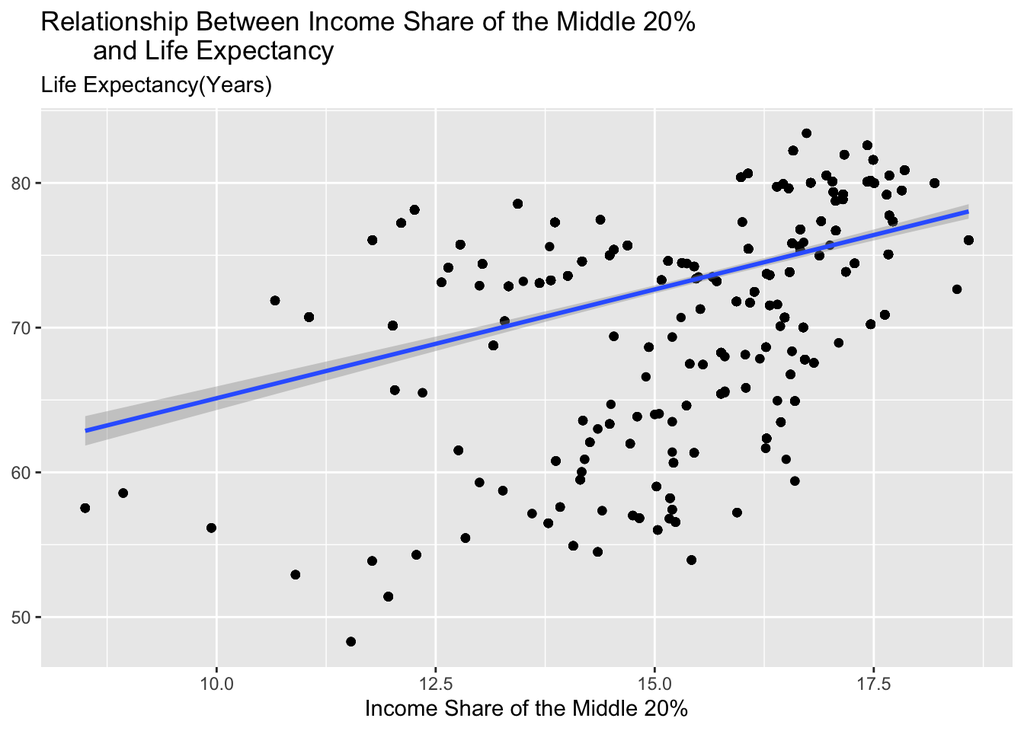

```r
joined_data |>
  group_by(country) |>
  mutate(life_ex = mean(life_ex)) |>
  mutate(income_share = mean(income_share))|>
  ggplot(aes(x = income_share,
             y = life_ex
             )
         ) +
  geom_point() +
  geom_smooth(method = "lm") +
  labs(x = "Income Share of the Middle 20%",
       subtitle = "Life Expectancy(Years)",
       title = "Relationship Between Income Share of the Middle 20%
       and Life Expectancy"
       ) +
  theme(axis.title.y = element_blank())
```

The following animated plot shows the relationship between income share of the middle 20% and life expectancy across years for each country that has data for the specified year. From the animated plot, we can see that more data on a country’s life expectancy and income share for the middle 20% became available as time went on. Also, the life expectancy and income share increased in most countries over time. Overall, it appears there is a positive correlation over the years, although some years have a less noticeable trend. In addition to allowing us to see trends in the data over the years this plot also demonstrates how certain years only contained data for a few countries. This resulted in us narrowing our data set further, only including years after 1979, as to ensure we had ample data points per year to evaluate trends in the data.

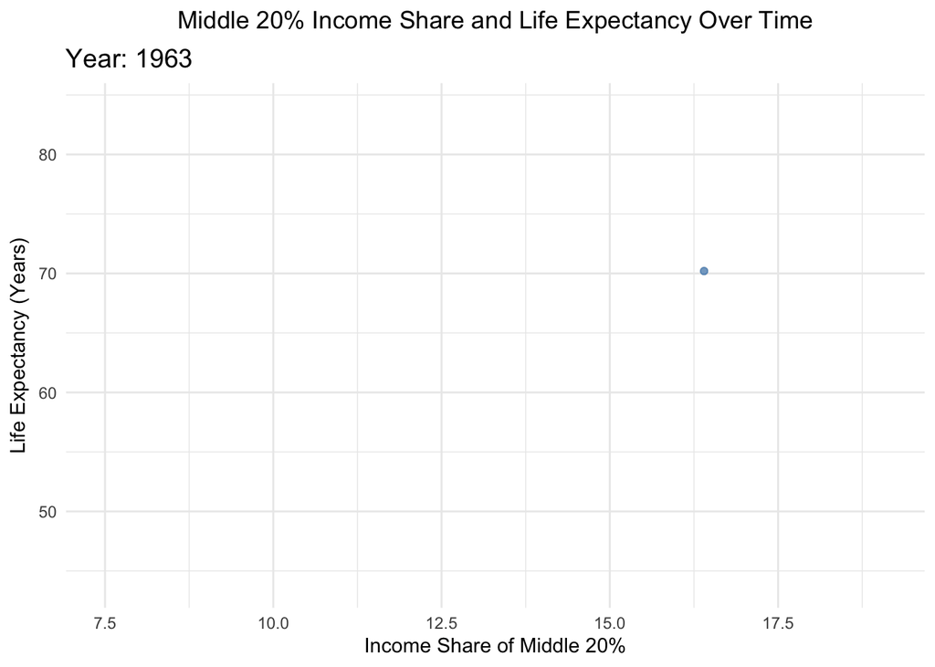

```r
data_anim <- joined_data |>
  ggplot(aes(x = income_share, y = life_ex)) +
  geom_point(alpha = 0.7, color = "steelblue") +
  labs(y = "Life Expectancy (Years)",
       x = "Income Share of Middle 20%",
       subtitle = "Year: {frame_time}",
        title = "Middle 20% Income Share and Life Expectancy Over Time") +
  theme_minimal() +
  theme(plot.subtitle = element_text(size = 14),
        plot.title = element_text(hjust = 0.5)) +
  transition_time(year) +
  ease_aes("linear")

animate(data_anim, nframes = 61, fps = 2, renderer = gifski_renderer("income_life_animation.gif"))
```

**Simple Linear Regression**

We used linear regression to visualize this data. Within this model, life expectancy was chosen as the response variable, and the income share of the middle 20% was chosen as the independent variable.

We followed the following formula when fitting our linear regression model:

$$\text{Y} = \beta_0 + \beta_1 x$$

With B<sub>0</sub> representing the intercept of the model and B<sub>1</sub> representing the linear coefficient, with x being the independent variable (income share of the middle 20%) and y being the response variable (life expectancy).

Additionally, the following table represents the simple linear regression model of the relationship between Life Expectancy and Income Share of the Middle 20%. The coefficients shown in the table tell us that if someone’s income share is 0, their predicted life expectancy is about 49.96 years. The coefficients also show that for each one percent increase in the income share of the middle 20%, the predicted life expectancy at birth for a country increases by approximately 1.52 years.

```r
joined_data <- joined_data |>
  filter(year >= 1980)
data_for_lm <- joined_data |>
  group_by(country) |>
  mutate(life_ex = mean(life_ex)) |>
  mutate(income_share = mean(income_share))
project_lm <- lm(life_ex ~ income_share,
                 data = data_for_lm)

kable(broom::tidy(project_lm))
```

| term | estimate | std.error | statistic | p.value |
| --- | --- | --- | --- | --- |
| (Intercept) | 49.966696 | 1.1340784 | 44.05930 | 0 |
| income_share | 1.515753 | 0.0725664 | 20.88781 | 0 |

**Checking Initial Model Fit**

The following table demonstrates the amount of variance in life expectancy explained by our model. Based on this data, it appears that the income share of the middle 20% explains approximately 17.5% of the variance in life expectancy at birth of a country. This percentage is surprisingly large, given how many other variables have an impact on the life expectancy of a country.

```r
lm_assess <-broom::augment(project_lm)
r2 <- broom::glance(project_lm)$r.squared
lm_assess |>
  ungroup() |>
  summarize("Variance in Response" = var(life_ex),
            "Variance of Predicted Values" = var(.fitted),
            "Variance of Residuals" = var(.resid),
            RSquared = r2) |>
  kable(caption = "Model Variances and R-Squared", align = "c") |>
  kable_styling(
    position = "center", font_size = 12)
```

Model Variances and R-Squared

| Variance in Response | Variance of Predicted Values | Variance of Residuals | RSquared |
| --- | --- | --- | --- |
| 48.49565 | 8.506687 | 39.98896 | 0.1754113 |

## Cross-Validation

```r
set.seed(14)

# randomly sample 20% of indices
test.idx <- sample(1:nrow(data_for_lm),
                   size = floor(nrow(data_for_lm)*.2))

# subset data for training set 80%
train_dat <- data_for_lm |>
  filter(!row_number() %in% test.idx)

# subset data for test set 20%
test_dat  <- data_for_lm  |>
  filter(row_number() %in% test.idx)
n <- nrow(data_for_lm)

# randomly partition into 10 folds
data_for_lm <- data_for_lm |>
  ungroup() |>
  mutate(fold = sample(rep_len(1:10, length.out = n),
                       size = n))
cv <- function(x, dataset){
  # separate fold (test) data
  fold_dat <- dataset |>
    filter(fold == x)

  # and training data
  train_dat <- dataset |>
    filter(fold != x)

  # fit model with training data
  it_lm <- lm(life_ex ~ income_share,
                 data = train_dat)

  # generate predictions for the held-out fold data
  fold_preds <- predict(it_lm, newdata = fold_dat)

  return (var(fold_preds)/var(fold_dat$life_ex))

}

cv_r2 <- map_dbl(.x = 1:10,
        .f = ~ cv(.x, data_for_lm))
```

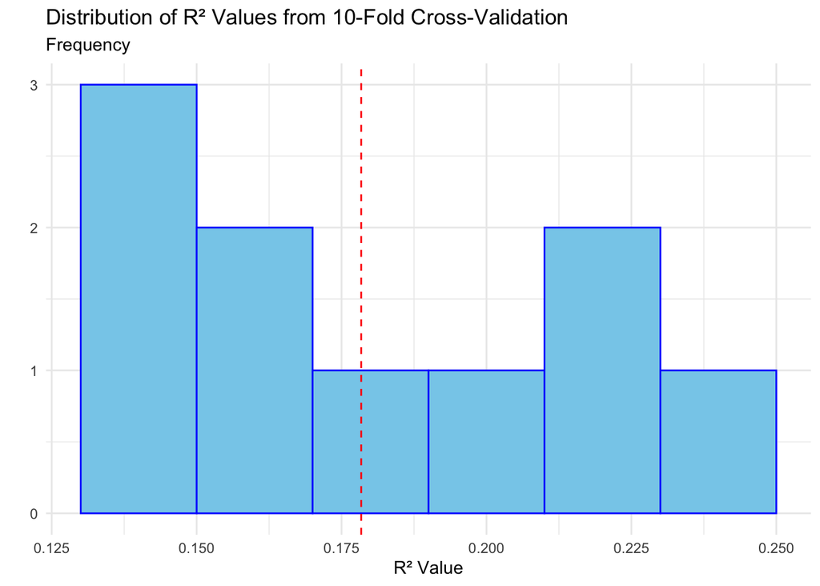

```r
#Code for R squared plot
avg_r2 <- mean(cv_r2)

cv_r2_results <- enframe(cv_r2, name = "fold", value = "r_squared")

cv_r2_results |>
  ggplot(aes(x=r_squared)) +
  geom_histogram(binwidth = 0.02, color = "blue", fill = "skyblue") +
  geom_vline(xintercept = avg_r2, color = "red", linetype = "dashed") +
  labs(x = "R² Value",
       y = "",
       subtitle = "Frequency",
       title = "Distribution of R² Values from 10-Fold Cross-Validation") +
  theme_minimal()
```

The mean R² ≈ 0.178 suggests that the model explains about 17.8% of the variance in life expectancy. This is quite substantial considering that only one variable is being used to predict life expectancy, which is quite complex.

R² values range from 0.125 to 0.25 across the 10 folds. This moderate variability indicates that the model’s performance is relatively consistent across different training/testing splits. No folds produce drastically low or high R², which supports model stability. There is no strong evidence of overfitting since R² values in cross-validation are consistent and not drastically lower than 0.178 (the mean). This means the model is generalizing reasonably well across folds.

## Works Cited and Project References

GitHub Reference Link: https://github.com/manavos/stat331-final-project.git

Chetty, Raj, et al. “The Association Between Income and Life Expectancy in the United States, 2001–2014.” JAMA, vol. 315, no. 16, 2016, pp. 1750–1766, doi:10.1001/jama.2016.4226.

Gapminder Foundation. “Gapminder Data.” Gapminder, https://www.gapminder.org/data/

Gapminder Foundation. “Gapminder Data Documentation GD004.” Gapminder, https://www.gapminder.org/data/documentation/gd004/

United Nations, Department of Economic and Social Affairs, Population Division. World Population Prospects. Accessed via Gapminder Foundation, https://www.gapminder.org/documentation/documentation/gapdoc004_v7.pdf

World Bank. “First-Time Fertility Rate Indicator (SI.DST.FRST.10).” World Bank Data, https://data.worldbank.org/indicator/SI.DST.FRST.10

Human Mortality Database. Accessed via Gapminder Foundation, https://www.gapminder.org/data/documentation/gd004/